# Simulacion en RocketPy

This notebook was generated using Rocket-Serializer, a RocketPy tool to convert simulation files to RocketPy simulations El notebook fue generado usando el siguiente archivo de parametros: `.\notebooks\simulacion_cohete.ipynb\parameters.json`

```python
# --- INYECCIÓN DINÁMICA DE LA GUI (NO ALTERA EL SCRIPT ORIGINAL) ---
LATITUD = 45.0
LONGITUD = 0.0
ELEVACION = 0.0
print('[GUI] Modo Atmósfera Estándar activado (Mantiene condiciones del .ork).')
```

```
[GUI] Modo Atmósfera Estándar activado (Mantiene condiciones del .ork).
```

```python
from rocketpy import Environment, SolidMotor, Rocket, Flight, TrapezoidalFins, EllipticalFins, RailButtons, NoseCone, Tail, Parachute
import datetime
```

```
Matplotlib is building the font cache; this may take a moment.
```

## Entorno

```
[OK] Entorno configurado: Atmosfera Estandar (ISA) y viento del .ork (2.00 m/s).

Gravity Details

Acceleration of gravity at surface level:    9.7803 m/s²
Acceleration of gravity at  80.000 km (ASL): 9.5379 m/s²


Launch Site Details

Launch Site Latitude: 45.00000°
Launch Site Longitude: 0.00000°
Reference Datum: SIRGAS2000
Launch Site UTM coordinates: 166021.44 W|E    0.00 N
Launch Site UTM zone: 31N
Launch Site Surface Elevation: 0.0 m


Atmospheric Model Details

Atmospheric Model Type: custom_atmosphere
custom_atmosphere Maximum Height: 80.000 km

Surface Atmospheric Conditions

Surface Wind Speed: 2.00 m/s
Surface Wind Direction: 90.00°
Surface Wind Heading: 270.00°
Surface Pressure: 1013.25 hPa
Surface Temperature: 288.15 K
Surface Air Density: 1.225 kg/m³
Surface Speed of Sound: 340.29 m/s


Earth Model Details

Earth Radius at Launch site: 6378.14 km
Semi-major Axis: 6378.14 km
Semi-minor Axis: 6356.75 km
Flattening: 0.0034



Gravity Model Plots
```

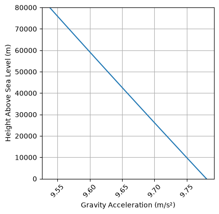

```
Atmospheric Model Plots
```

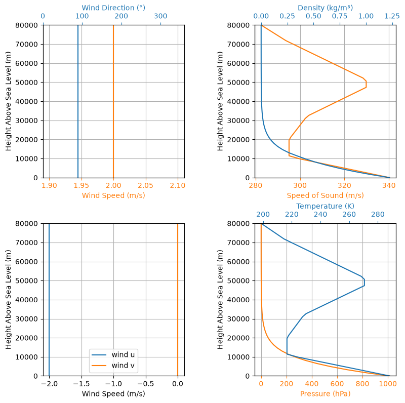

```python
from rocketpy import Environment
import datetime
import requests
import math

# ==========================================
# 1. BLOQUE DE CONFIGURACION (EXTRAIDO DEL .ORK)
# ==========================================
# Estas coordenadas fueron extraidas directamente de tu archivo OpenRocket
# GUI OVERRIDE: LATITUD = 45.0
# GUI OVERRIDE: LONGITUD = 0.0
# GUI OVERRIDE: ELEVACION = 0.0

# ==========================================
# 2. INICIALIZACION GEOGRAFICA EXACTA (t=0)
# ==========================================
# Respeto absoluto a la causalidad fisica: El punto de lanzamiento es estrictamente el origen (t=0).
env = Environment()
env.set_location(LATITUD, LONGITUD)
env.set_elevation(ELEVACION)

try:
    # Calculo de componentes de viento a partir de los datos de OpenRocket
    wind_speed = 2.0
    wind_dir_rad = 1.5707963267948966 # Radianes desde el Norte
    # En meteorologia (y OpenRocket), la direccion es de donde VIENE el viento.
    # Para RocketPy, wind_u es hacia el Este (+X), wind_v es hacia el Norte (+Y).
    wind_u = -wind_speed * math.sin(wind_dir_rad)
    wind_v = -wind_speed * math.cos(wind_dir_rad)

    # OpenRocket esta configurado para usar Atmosfera Estandar (ISA)
    env.set_atmospheric_model(type='standard_atmosphere')
    # RocketPy requiere llamar a custom_atmosphere para inyectar viento sobre ISA
    env.set_atmospheric_model(
        type='custom_atmosphere',
        wind_u=wind_u,
        wind_v=wind_v
    )
    print(f'[OK] Entorno configurado: Atmosfera Estandar (ISA) y viento del .ork ({wind_speed:.2f} m/s).')

except Exception as e:
    print(f'[ADVERTENCIA] Hubo un error al configurar la atmosfera: {e}')
    env.set_atmospheric_model(type='standard_atmosphere')

env.all_info()
```

## Motor

Currently, only Solid Motors are supported by Rocket-Serializer. If you want to use a Liquid/Hybrid motor, please use rocketpy directly.

```python
motor = SolidMotor(
    thrust_source='thrust_source.csv',
    dry_mass=0,
    dry_inertia=[0.001, 0.001, 0.001],
    center_of_dry_mass_position=0,
    grains_center_of_mass_position=0,
    grain_number=1,
    grain_density=224.5572389303639,
    grain_outer_radius=0.009,
    grain_initial_inner_radius=0.0045,
    grain_initial_height=0.07,
    grain_separation=0,
    nozzle_radius=0.006749999999999999,
    nozzle_position=0.035,
    throat_radius=0.0045,
    reshape_thrust_curve=False,  # Not implemented in Rocket-Serializer
    interpolation_method='linear',
    coordinate_system_orientation='combustion_chamber_to_nozzle',
)
```

```
Nozzle Details
Nozzle Radius: 0.006749999999999999 m
Nozzle Throat Radius: 0.0045 m

Grain Details
Number of Grains: 1
Grain Spacing: 0 m
Grain Density: 224.5572389303639 kg/m3
Grain Outer Radius: 0.009 m
Grain Inner Radius: 0.0045 m
Grain Height: 0.07 m
Grain Volume: 0.000 m3
Grain Mass: 0.003 kg

Motor Details
Total Burning Time: 0.726 s
Total Propellant Mass: 0.003 kg
Structural Mass Ratio: 0.000
Average Propellant Exhaust Velocity: 773.234 m/s
Average Thrust: 3.240 N
Maximum Thrust: 9.73 N at 0.226 s after ignition.
Total Impulse: 2.320 Ns
```

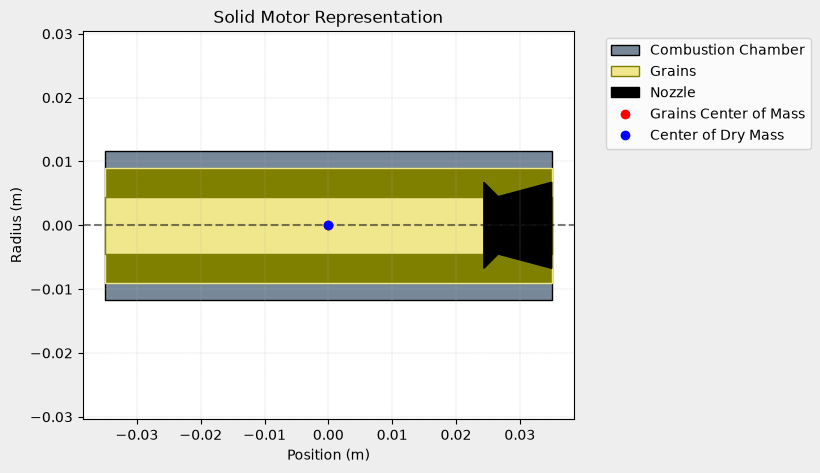

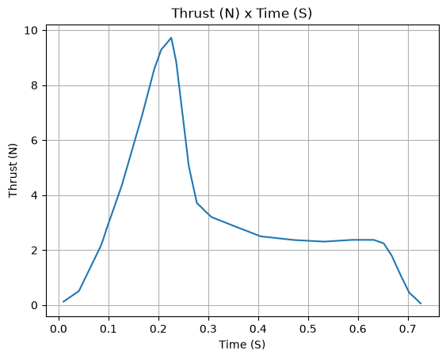

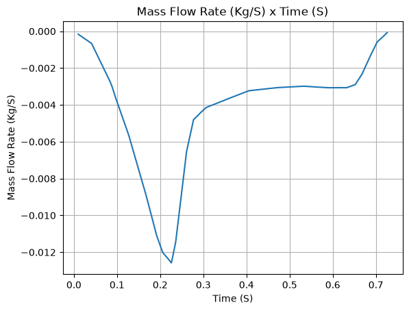

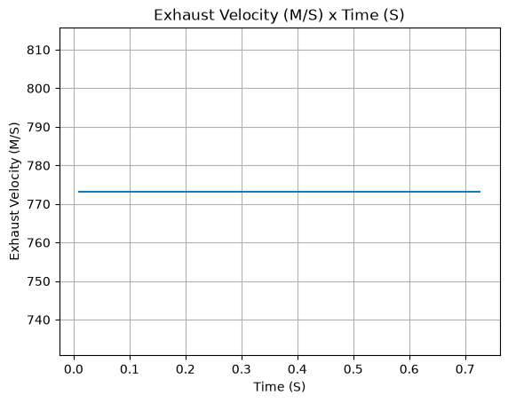

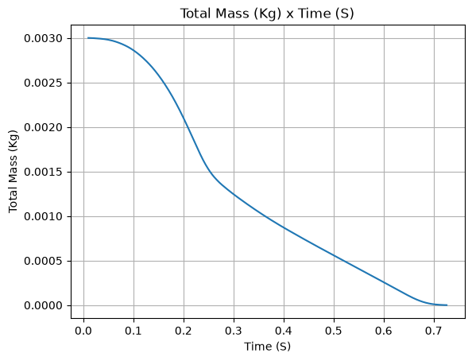

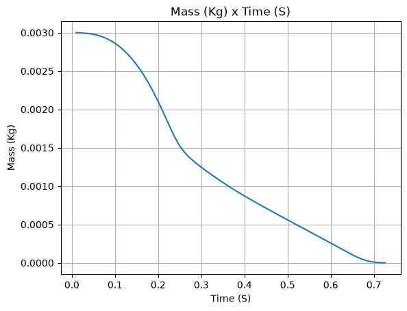

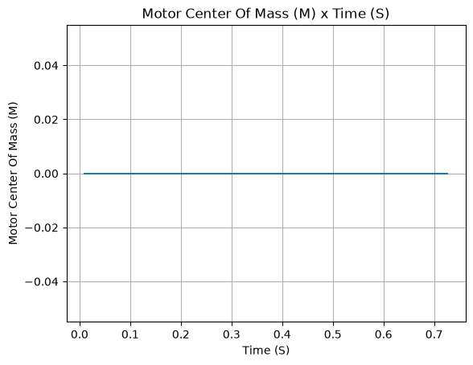

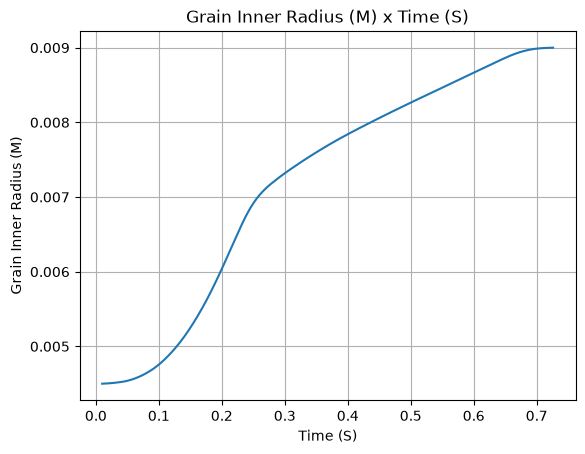

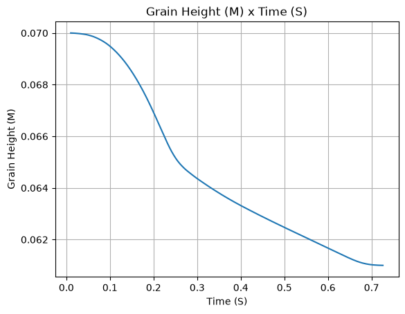

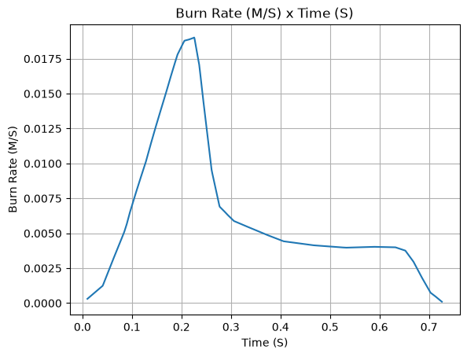

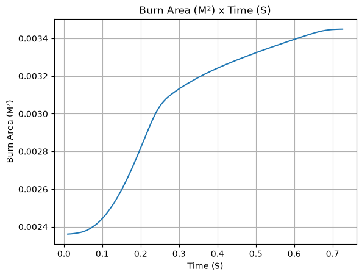

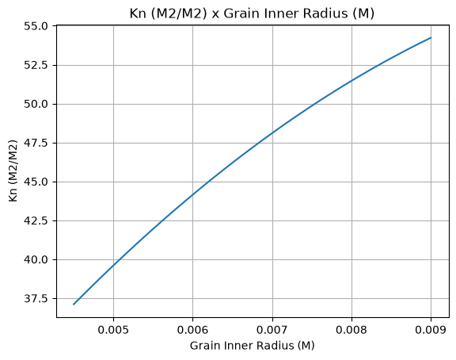

[1 more figures not shown]

```python
motor.all_info()
```

## Cohete

Currently, only single stage rockets are supported by Rocket-Serializer We will start by defining the aerodynamic surfaces, and then build the rocket.

### Ojivas (Nosecones)

```python
nosecone = NoseCone(
    length=0.1,
    kind='ogive',
    base_radius=0.0125,
    rocket_radius=0.0125,
    name='0.1',
)
```

### Aletas (Fins)

As rocketpy allows for multiple fins sets, we will create a dictionary with all the fins sets and then add them to the rocket

```python
trapezoidal_fins = {}
```

```python
trapezoidal_fins[0] = TrapezoidalFins(
    n=3,
    root_chord=0.0508,
    tip_chord=0.0508,
    span=0.03,
    cant_angle=0.0,
    sweep_length= 0.0254,
    sweep_angle= None,
    rocket_radius=0.0125,
    name='Trapezoidal fin set',
)
```

### Transiciones / Colas (Tails)

As rocketpy allows for multiple tails, we will create a dictionary with all the tails and then add them to the rocket

```python
tails = {}
```

### Paracaidas

As rocketpy allows for multiple parachutes, we will create a dictionary with all the parachutes and then add them to the rocket

```python
parachutes = {}
```

```python
parachutes = {}
parachutes[0] = Parachute(
    name='Parachute',
    cd_s=0.071,
    trigger='apogee',
    sampling_rate=100,
)
```

```python
rocket = Rocket(
    radius=0.0125,
    mass=0.062,
    inertia=[0.000974, 0.000974, 9.895e-06],
    power_off_drag='drag_curve.csv',
    power_on_drag='drag_curve.csv',
    center_of_mass_without_motor=0.242,
    coordinate_system_orientation='nose_to_tail',
)
```

### Agregando superficies al cohete

Ahora que tenemos todas las superficies, podemos agregarlas al cohete

```python
# ============================================================
# CCTE: Extracción Geométrica Dinámica del .ork
# Calcula posiciones absolutas en tiempo de ejecución.
# ============================================================
import sys, os

# Resolver ruta raíz robustamente (buscando la carpeta 'scripts')
_root = os.getcwd()
while not os.path.exists(os.path.join(_root, 'scripts')) and _root != os.path.dirname(_root):
    _root = os.path.dirname(_root)

sys.path.append(os.path.join(_root, 'scripts'))
from ork_geometry import OrkGeometry

_ork_path = os.path.join(_root, 'disenos', 'cohete.ork')
if os.path.exists(_ork_path):
    geo = OrkGeometry(_ork_path)
    FIN_POSITION_ABSOLUTE = geo.first_fin_set.fin_leading_edge if geo.first_fin_set else 0.0
    print(f'Geometría dinámica cargada. Aletas en: {FIN_POSITION_ABSOLUTE:.4f}m desde la nariz')
else:
    print('Advertencia: cohete.ork no encontrado.')
    FIN_POSITION_ABSOLUTE = 0.0
```

```
Geometría dinámica cargada. Aletas en: 0.3492m desde la nariz
```

```python
rocket.add_surfaces(surfaces=[nosecone, trapezoidal_fins[0]], positions=[0.0, FIN_POSITION_ABSOLUTE])
```

```python
rocket.add_motor(motor, position= 0.37199999999999933)
```

Agregando paracaidas al cohete

```python
rocket.parachutes = list(parachutes.values())
```

### Botones de Riel (Rail Buttons)

```python
# No se agregaron botones de riel al cohete.
```

```
Inertia Details

Rocket Mass: 0.062 kg (without motor)
Rocket Dry Mass: 0.062 kg (with unloaded motor)
Rocket Loaded Mass: 0.065 kg
Rocket Structural Mass Ratio: 0.954
Rocket Inertia (with unloaded motor) 11: 0.002 kg*m2
Rocket Inertia (with unloaded motor) 22: 0.002 kg*m2
Rocket Inertia (with unloaded motor) 33: 0.001 kg*m2
Rocket Inertia (with unloaded motor) 12: 0.000 kg*m2
Rocket Inertia (with unloaded motor) 13: 0.000 kg*m2
Rocket Inertia (with unloaded motor) 23: 0.000 kg*m2

Geometrical Parameters

Rocket Maximum Radius: 0.0125 m
Rocket Frontal Area: 0.000491 m2

Rocket Distances
Rocket Center of Dry Mass - Center of Mass without Motor: 0.000 m
Rocket Center of Dry Mass - Nozzle Exit: 0.165 m
Rocket Center of Dry Mass - Center of Propellant Mass: 0.130 m
Rocket Center of Mass - Rocket Loaded Center of Mass: 0.006 m


Aerodynamics Lift Coefficient Derivatives

0.1 Lift Coefficient Derivative: 2.000/rad
Trapezoidal fin set Lift Coefficient Derivative: 9.876/rad

Center of Pressure

0.1 Center of Pressure position: 0.046 m
Trapezoidal fin set Center of Pressure position: 0.375 m

Stability

Center of Mass position (time=0): 0.248 m
Center of Pressure position (time=0): 0.319 m
Initial Static Margin (mach=0, time=0): 2.853 c
Final Static Margin (mach=0, time=burn_out): 3.093 c
Rocket Center of Mass (time=0) - Center of Pressure (mach=0): 0.071 m


Parachute Details

Parachute Parachute with a cd_s of 0.0710 m2
Ejection signal trigger: At Apogee
Ejection system refresh rate: 100.000 Hz
Time between ejection signal is triggered and the parachute is fully opened: 0.0 s


Rocket Draw
----------------------------------------
```

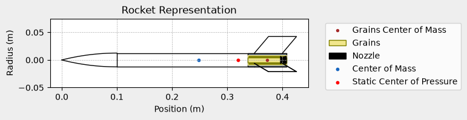

```
Mass Plots
----------------------------------------
```

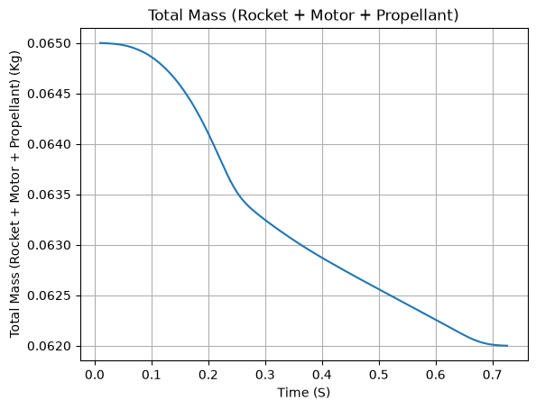

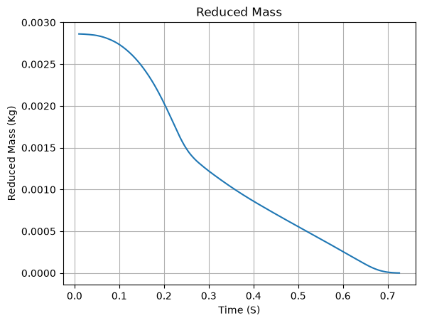

```
Aerodynamics Plots
----------------------------------------
Drag Plots
--------------------
```

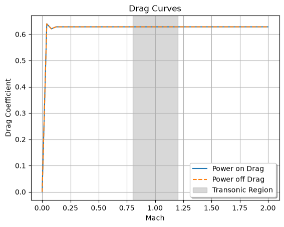

```
Stability Plots
--------------------
```

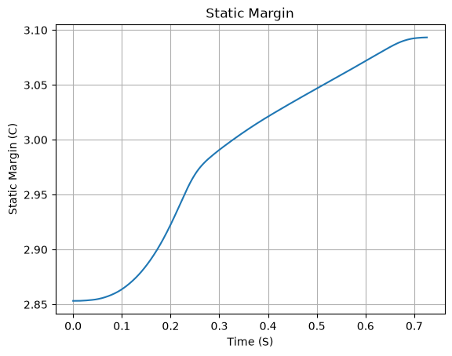

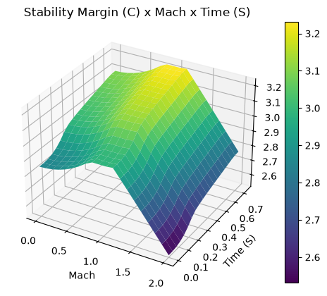

```
Thrust-to-Weight Plot
----------------------------------------
```

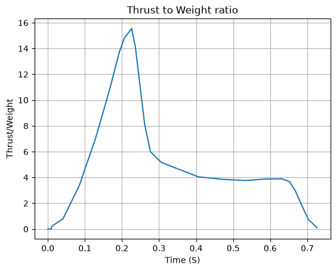

```python
### Informacion del Cohete
rocket.all_info()
```

## Flight

We will now create the flight simulation. Let's go!

```python
flight = Flight(
    rocket=rocket,
    environment=env,
    rail_length=1.0,
    inclination=90.0,
    heading=90.0,
    terminate_on_apogee=False,
    max_time=600,
)
```

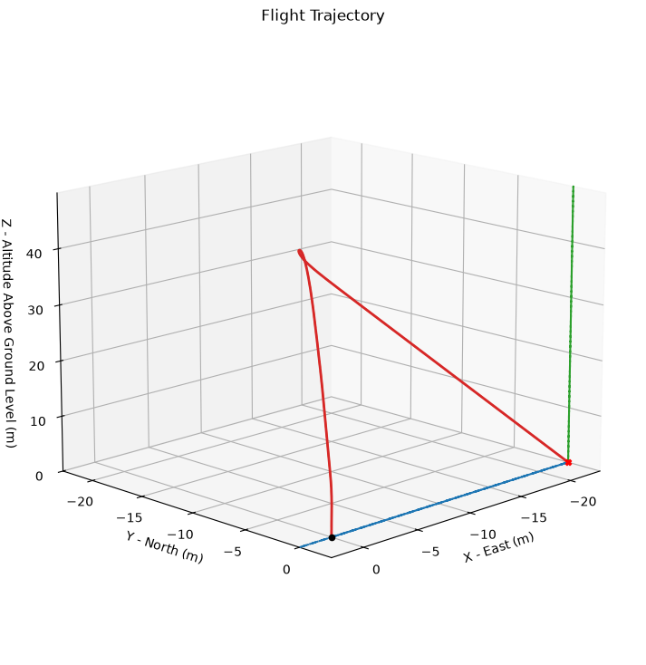

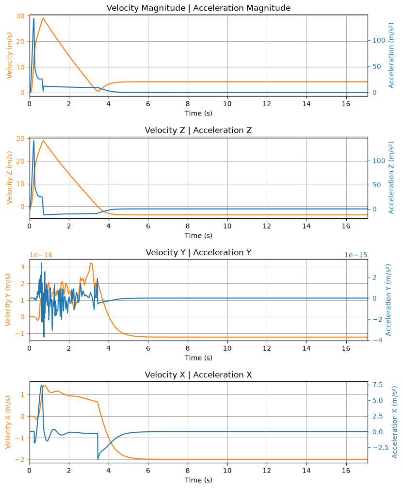

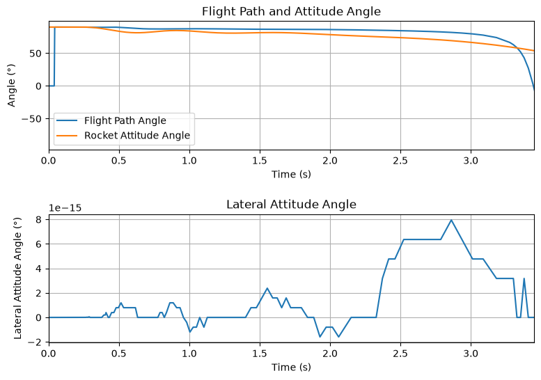

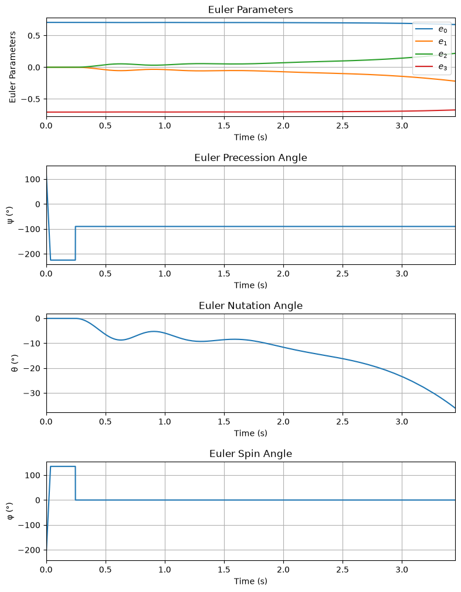

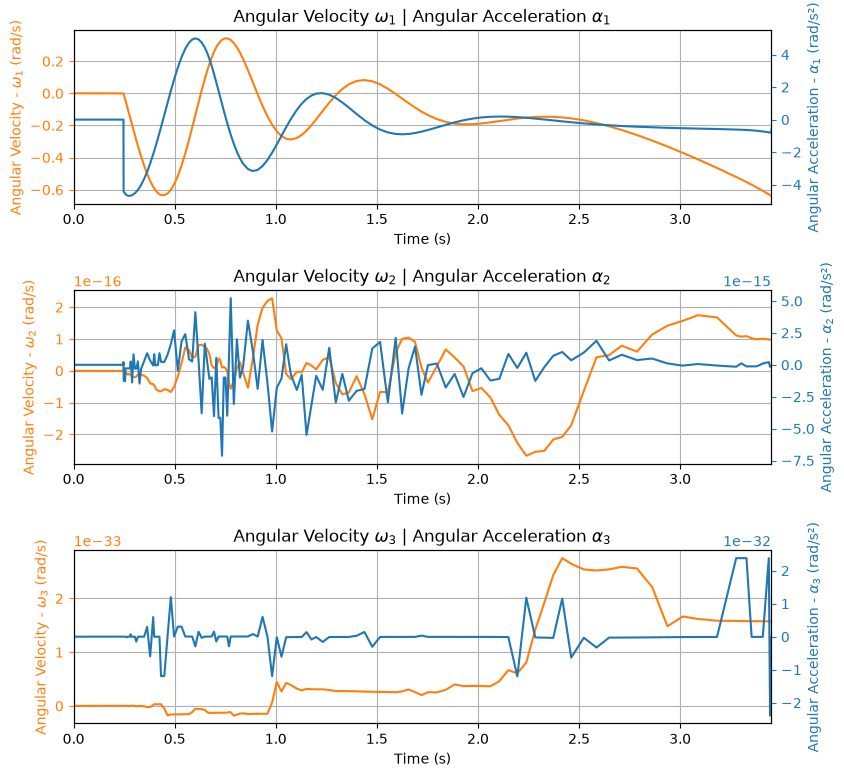

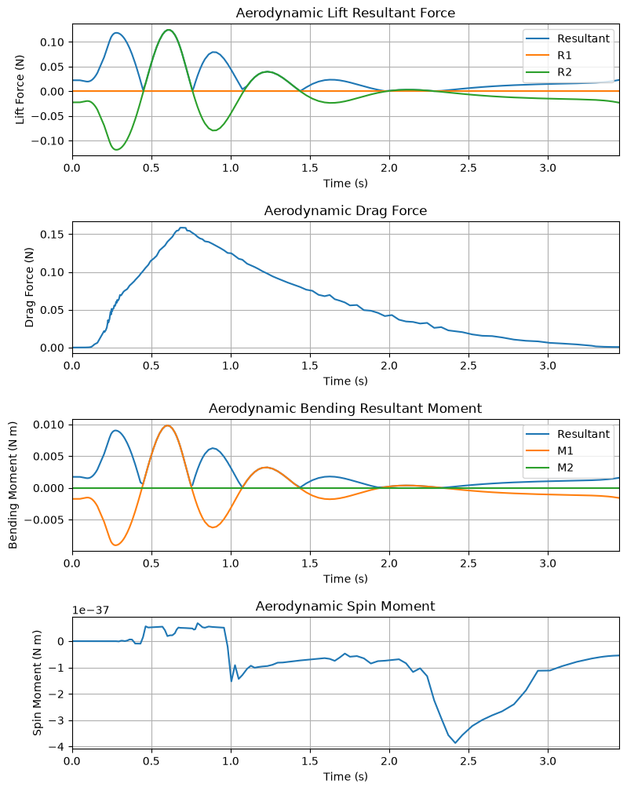

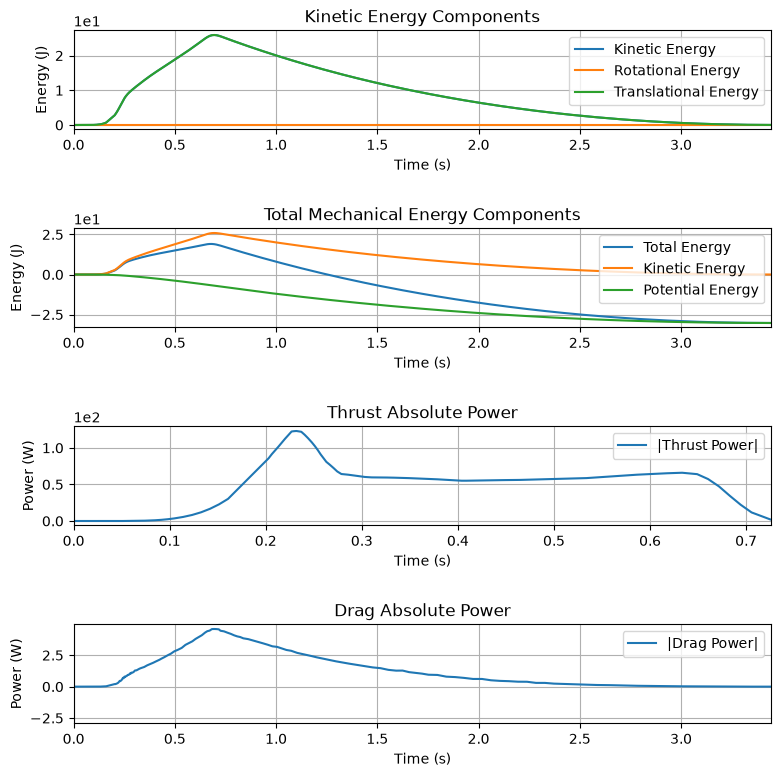

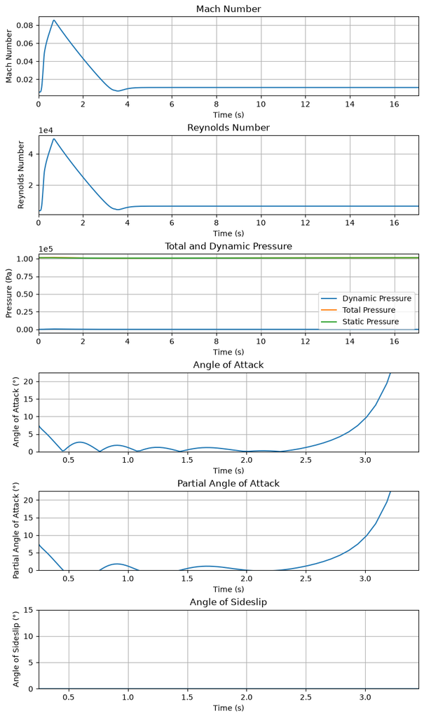

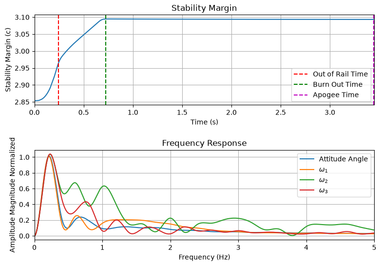

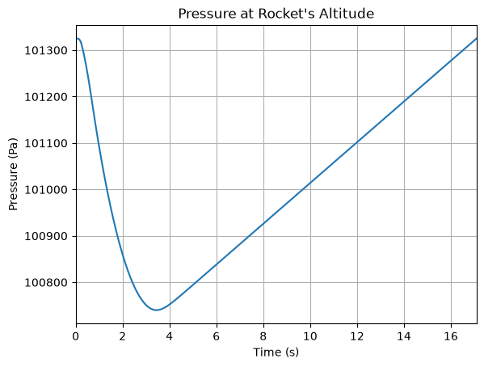

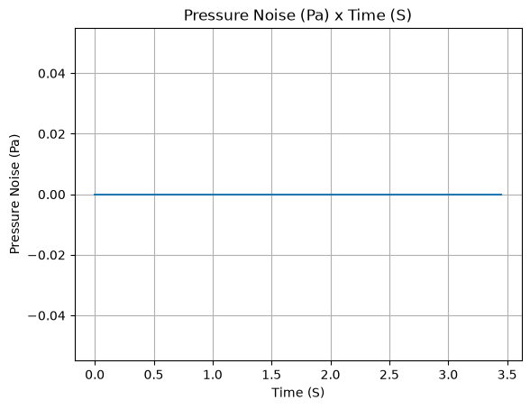

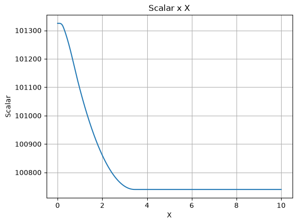

[1 more figures not shown]

```
Initial Conditions

Initial time: 0.000 s
Position - x: 0.00 m | y: 0.00 m | z: 0.00 m
Velocity - Vx: 0.00 m/s | Vy: 0.00 m/s | Vz: 0.00 m/s
Attitude (quaternions) - e0: 0.707 | e1: 0.000 | e2: 0.000 | e3: -0.707
Euler Angles - Spin φ : -225.00° | Nutation θ: 0.00° | Precession ψ: 135.00°
Angular Velocity - ω1: 0.00 rad/s | ω2: 0.00 rad/s | ω3: 0.00 rad/s
Initial Stability Margin: 2.853 c


Surface Wind Conditions

Frontal Surface Wind Speed: -2.00 m/s
Lateral Surface Wind Speed: 0.00 m/s


Launch Rail

Launch Rail Length: 1.0 m
Launch Rail Inclination: 90.00°
Launch Rail Heading: 90.00°


Rail Departure State

Rail Departure Time: 0.247 s
Rail Departure Velocity: 15.134 m/s
Rail Departure Stability Margin: 2.966 c
Rail Departure Angle of Attack: 7.528°
Rail Departure Thrust-Weight Ratio: 11.609
Rail Departure Reynolds Number: 2.612e+04


Burn out State

Burn out time: 0.726 s
Altitude at burn out: 12.401 m (ASL) | 12.401 m (AGL)
Rocket speed at burn out: 28.703 m/s
Freestream velocity at burn out: 28.872 m/s
```

[output cut: 111 more lines]

```
Trajectory Fluid Mechanics Plots



Trajectory Stability and Control Plots



Rocket and Parachute Pressure Plots


Parachute:  Parachute


[SISTEMA] Reporte tecnico guardado exitosamente en reporte_mision_urgente.txt
```

```python
import io
from contextlib import redirect_stdout

# Capturar salida de flight.all_info()
f_out = io.StringIO()
with redirect_stdout(f_out):
    flight.all_info()

out_str = f_out.getvalue()
print(out_str)  # Mantener salida visible en consola

# Guardar silenciosamente en archivo de texto en la raiz del proyecto
with open('../../reporte_mision_urgente.txt', 'w', encoding='utf-8') as f:
    f.write(out_str)
print('\n[SISTEMA] Reporte tecnico guardado exitosamente en reporte_mision_urgente.txt')
```

## Comparacion de Resultados

We will now compare the results of the simulation with the parameters used to create it. Let's go!

```python
### Parametros: OpenRocket vs RocketPy
time_to_apogee_ork = 3.476
time_to_apogee_rpy = flight.apogee_time
print(f"Tiempo hasta el apogeo (OpenRocket): {time_to_apogee_ork:.3f} s")
print(f"Tiempo hasta el apogeo (RocketPy):   {time_to_apogee_rpy:.3f} s")
apogee_difference = time_to_apogee_rpy - time_to_apogee_ork
error = abs((apogee_difference)/ (time_to_apogee_rpy if time_to_apogee_rpy != 0 else 1e-9)) * 100
print(f"Tiempo hasta el apogeo (diferencia):   {error:.3f} %")
print()

flight_time_ork = 15.849
flight_time_rpy = flight.t_final
print(f"Tiempo de vuelo (OpenRocket): {flight_time_ork:.3f} s")
print(f"Tiempo de vuelo (RocketPy):   {flight_time_rpy:.3f} s")
flight_time_difference = flight_time_rpy - flight_time_ork
error_flight_time = abs((flight_time_difference)/ (flight_time_rpy if flight_time_rpy != 0 else 1e-9)) * 100
print(f"Tiempo de vuelo (diferencia):   {error_flight_time:.3f} %")
print()

ground_hit_velocity_ork = -4.633
ground_hit_velocity_rpy = flight.impact_velocity
print(f"Velocidad de impacto (OpenRocket): {ground_hit_velocity_ork:.3f} m/s")
print(f"Velocidad de impacto (RocketPy):   {ground_hit_velocity_rpy:.3f} m/s")
ground_hit_velocity_difference = ground_hit_velocity_rpy - ground_hit_velocity_ork
error_ground_hit_velocity = abs((ground_hit_velocity_difference)/ (ground_hit_velocity_rpy if ground_hit_velocity_rpy != 0 else 1e-9)) * 100
print(f"Velocidad de impacto (diferencia):   {error_ground_hit_velocity:.3f} %")
print()

launch_rod_velocity_ork = 15.365
launch_rod_velocity_rpy = flight.out_of_rail_velocity
print(f"Velocidad de salida del riel (OpenRocket): {launch_rod_velocity_ork:.3f} m/s")
print(f"Velocidad de salida del riel (RocketPy):   {launch_rod_velocity_rpy:.3f} m/s")
launch_rod_velocity_difference = launch_rod_velocity_rpy - launch_rod_velocity_ork
error_launch_rod_velocity = abs((launch_rod_velocity_difference)/ (launch_rod_velocity_rpy if launch_rod_velocity_rpy != 0 else 1e-9)) * 100
print(f"Velocidad de salida del riel (diferencia):   {error_launch_rod_velocity:.3f} %")
print()

max_acceleration_ork = 143.641
max_acceleration_rpy = flight.max_acceleration
print(f"Aceleracion maxima (OpenRocket): {max_acceleration_ork:.3f} m/s²")
print(f"Aceleracion maxima (RocketPy):   {max_acceleration_rpy:.3f} m/s²")
max_acceleration_difference = max_acceleration_rpy - max_acceleration_ork
error_max_acceleration = abs((max_acceleration_difference)/ (max_acceleration_rpy if max_acceleration_rpy != 0 else 1e-9)) * 100
print(f"Aceleracion maxima (diferencia):   {error_max_acceleration:.3f} %")
print()

max_altitude_ork = 50.436
max_altitude_rpy = flight.apogee - flight.env.elevation
print(f"Altitud maxima (OpenRocket): {max_altitude_ork:.3f} m")
print(f"Altitud maxima (RocketPy):   {max_altitude_rpy:.3f} m")
max_altitude_difference = max_altitude_rpy - max_altitude_ork
error_max_altitude = abs((max_altitude_difference)/ (max_altitude_rpy if max_altitude_rpy != 0 else 1e-9)) * 100
print(f"Altitud maxima (diferencia):   {error_max_altitude:.3f} %")
print()

max_mach_ork = 0.086
max_mach_rpy = flight.max_mach_number
print(f"Mach maximo (OpenRocket): {max_mach_ork:.3f}")
print(f"Mach maximo (RocketPy):   {max_mach_rpy:.3f}")
max_mach_difference = max_mach_rpy - max_mach_ork
error_max_mach = abs((max_mach_difference)/ (max_mach_rpy if max_mach_rpy != 0 else 1e-9)) * 100
print(f"Mach maximo (diferencia):   {error_max_mach:.3f} %")
print()

max_velocity_ork = 29.209
max_velocity_rpy = flight.max_speed
print(f"Velocidad maxima (OpenRocket): {max_velocity_ork:.3f} m/s")
print(f"Velocidad maxima (RocketPy):   {max_velocity_rpy:.3f} m/s")
max_velocity_difference = max_velocity_rpy - max_velocity_ork
error_max_velocity = abs((max_velocity_difference)/ (max_velocity_rpy if max_velocity_rpy != 0 else 1e-9)) * 100
print(f"Velocidad maxima (diferencia):   {error_max_velocity:.3f} %")
print()

max_thrust_ork = 9.73
max_thrust_rpy = flight.rocket.motor.thrust.max
print(f"Empuje maximo (OpenRocket): {max_thrust_ork:.3f} N")
print(f"Empuje maximo (RocketPy):   {max_thrust_rpy:.3f} N")
max_thrust_difference = max_thrust_rpy - max_thrust_ork
error_max_thrust = abs((max_thrust_difference)/ (max_thrust_rpy if max_thrust_rpy != 0 else 1e-9)) * 100
print(f"Empuje maximo (diferencia):   {error_max_thrust:.3f} %")
print()

burnout_stability_margin_ork = 2.946
burnout_stability_margin_rpy = flight.stability_margin(flight.rocket.motor.burn_out_time)
print(f"Margen de estabilidad (Burnout) (OpenRocket): {burnout_stability_margin_ork:.3f}")
print(f"Margen de estabilidad (Burnout) (RocketPy):   {burnout_stability_margin_rpy:.3f}")
burnout_stability_margin_difference = burnout_stability_margin_rpy - burnout_stability_margin_ork
error_burnout_stability_margin = abs((burnout_stability_margin_difference)/ (burnout_stability_margin_rpy if burnout_stability_margin_rpy != 0 else 1e-9)) * 100
print(f"Margen de estabilidad (Burnout) (diferencia):   {error_burnout_stability_margin:.3f} %")
print()

max_stability_margin_ork = 3.302
max_stability_margin_rpy = flight.max_stability_margin
print(f"Margen de estabilidad maximo (OpenRocket): {max_stability_margin_ork:.3f}")
print(f"Margen de estabilidad maximo (RocketPy):   {max_stability_margin_rpy:.3f}")
max_stability_margin_difference = max_stability_margin_rpy - max_stability_margin_ork
error_max_stability_margin = abs((max_stability_margin_difference)/ (max_stability_margin_rpy if max_stability_margin_rpy != 0 else 1e-9)) * 100
print(f"Margen de estabilidad maximo (diferencia):   {error_max_stability_margin:.3f} %")
print()

min_stability_margin_ork = 0.0
min_stability_margin_rpy = flight.min_stability_margin
print(f"Margen de estabilidad minimo (OpenRocket): {min_stability_margin_ork:.3f}")
print(f"Margen de estabilidad minimo (RocketPy):   {min_stability_margin_rpy:.3f}")
min_stability_margin_difference = min_stability_margin_rpy - min_stability_margin_ork
error_min_stability_margin = abs((min_stability_margin_difference)/ (min_stability_margin_rpy if min_stability_margin_rpy != 0 else 1e-9)) * 100
print(f"Margen de estabilidad minimo (diferencia):   {error_min_stability_margin:.3f} %")
print()
```

```
Tiempo hasta el apogeo (OpenRocket): 3.476 s
Tiempo hasta el apogeo (RocketPy):   3.445 s
Tiempo hasta el apogeo (diferencia):   0.905 %

Tiempo de vuelo (OpenRocket): 15.849 s
Tiempo de vuelo (RocketPy):   17.091 s
Tiempo de vuelo (diferencia):   7.268 %

Velocidad de impacto (OpenRocket): -4.633 m/s
Velocidad de impacto (RocketPy):   -3.734 m/s
Velocidad de impacto (diferencia):   24.065 %

Velocidad de salida del riel (OpenRocket): 15.365 m/s
Velocidad de salida del riel (RocketPy):   15.134 m/s
Velocidad de salida del riel (diferencia):   1.529 %

Aceleracion maxima (OpenRocket): 143.641 m/s²
Aceleracion maxima (RocketPy):   141.002 m/s²
Aceleracion maxima (diferencia):   1.872 %

Altitud maxima (OpenRocket): 50.436 m
Altitud maxima (RocketPy):   49.825 m
Altitud maxima (diferencia):   1.226 %

Mach maximo (OpenRocket): 0.086
Mach maximo (RocketPy):   0.085
Mach maximo (diferencia):   0.630 %

Velocidad maxima (OpenRocket): 29.209 m/s
Velocidad maxima (RocketPy):   28.913 m/s
Velocidad maxima (diferencia):   1.022 %

Empuje maximo (OpenRocket): 9.730 N
Empuje maximo (RocketPy):   9.730 N
Empuje maximo (diferencia):   0.000 %

Margen de estabilidad (Burnout) (OpenRocket): 2.946
Margen de estabilidad (Burnout) (RocketPy):   3.095
Margen de estabilidad (Burnout) (diferencia):   4.803 %

Margen de estabilidad maximo (OpenRocket): 3.302
Margen de estabilidad maximo (RocketPy):   3.095
Margen de estabilidad maximo (diferencia):   6.700 %

Margen de estabilidad minimo (OpenRocket): 0.000
Margen de estabilidad minimo (RocketPy):   2.853
Margen de estabilidad minimo (diferencia):   100.000 %
```

## Visualizacion y Telemetria

Visualizacion en 3D de la trayectoria y exportacion logistica.

```
Initial Conditions

Initial time: 0.000 s
Position - x: 0.00 m | y: 0.00 m | z: 0.00 m
Velocity - Vx: 0.00 m/s | Vy: 0.00 m/s | Vz: 0.00 m/s
Attitude (quaternions) - e0: 0.707 | e1: 0.000 | e2: 0.000 | e3: -0.707
Euler Angles - Spin φ : -225.00° | Nutation θ: 0.00° | Precession ψ: 135.00°
Angular Velocity - ω1: 0.00 rad/s | ω2: 0.00 rad/s | ω3: 0.00 rad/s
Initial Stability Margin: 2.853 c


Surface Wind Conditions

Frontal Surface Wind Speed: -2.00 m/s
Lateral Surface Wind Speed: 0.00 m/s


Launch Rail

Launch Rail Length: 1.0 m
Launch Rail Inclination: 90.00°
Launch Rail Heading: 90.00°


Rail Departure State

Rail Departure Time: 0.247 s
Rail Departure Velocity: 15.134 m/s
Rail Departure Stability Margin: 2.966 c
Rail Departure Angle of Attack: 7.528°
Rail Departure Thrust-Weight Ratio: 11.609
Rail Departure Reynolds Number: 2.612e+04


Burn out State

Burn out time: 0.726 s
Altitude at burn out: 12.401 m (ASL) | 12.401 m (AGL)
Rocket speed at burn out: 28.703 m/s
Freestream velocity at burn out: 28.872 m/s
```

[output cut: 55 more lines]

```



Numerical Integration Settings

Maximum Allowed Flight Time: 600.00 s
Maximum Allowed Time Step: inf s
Minimum Allowed Time Step: 0.00e+00 s
Relative Error Tolerance: 1e-06
Absolute Error Tolerance: [0.001, 0.001, 0.001, 0.001, 0.001, 0.001, 1e-06, 1e-06, 1e-06, 1e-06, 0.001, 0.001, 0.001]
Allow Event Overshoot: True
Terminate Simulation on Apogee: False
Number of Time Steps Used: 204
Number of Derivative Functions Evaluation: 115
Average Function Evaluations per Time Step: 0.564
```

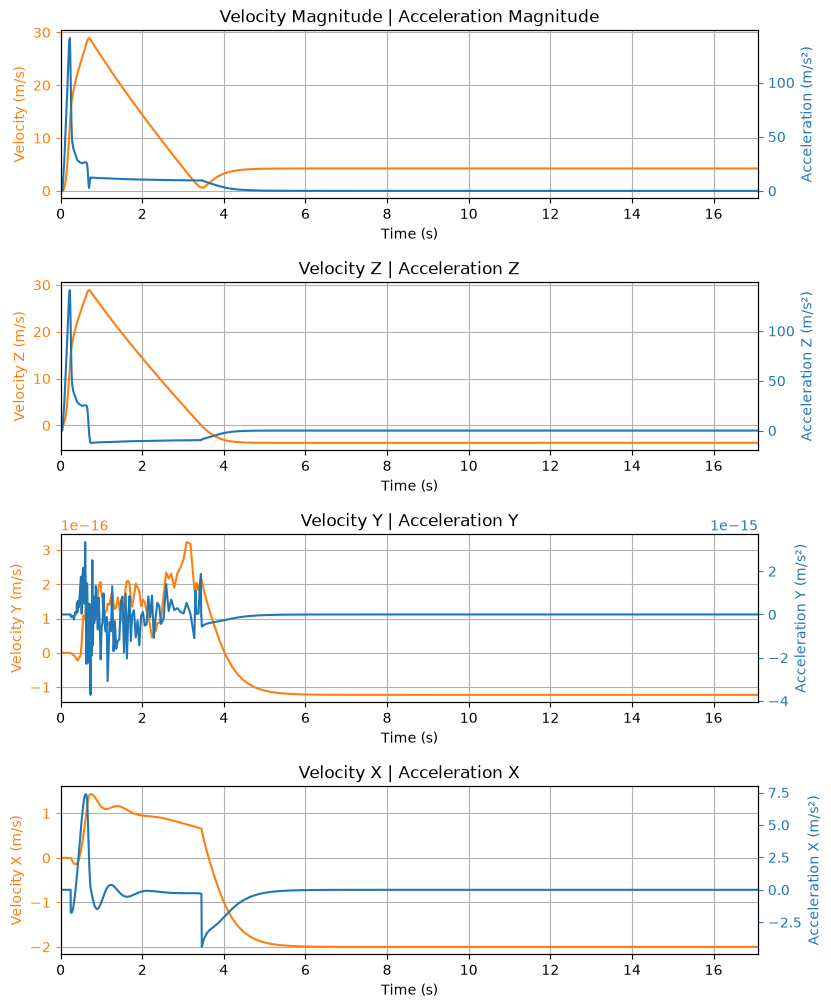

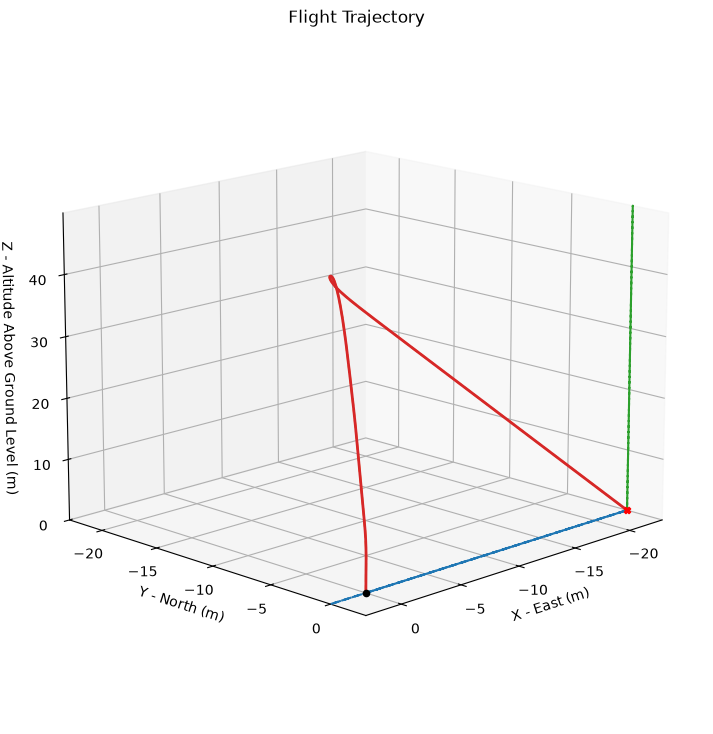

```
[SISTEMA] --- REPORTE DE NAVEGACION ---
-> PUNTO DE INICIO (Rampa)     : 45.000000, 0.000000  <-- Coordenadas ingresadas
-> PUNTO DE FINAL (Aterrizaje) : 45.000000, -0.000293
-> Deriva Balistica Total      : 23.05 metros
File  ../../resultados/trayectoria_operativa.kml  saved with success!
[SISTEMA] Archivo KML generado en /resultados para visualizacion espacial.
[SISTEMA] Matriz de vuelo exportada a CSV en /resultados con exito.

[SISTEMA] --- REPORTE DE RECUPERACION ---
Paracaidas: Parachute | Tiempo: 3.45 s | Altitud AGL: 49.82 m
-------------------------------------------
```

```python
flight.info()
flight.plots.linear_kinematics_data()
flight.plots.trajectory_3d()

# ==========================================
# MODULO DE RECUPERACION Y TELEMETRIA
# ==========================================
import os
from rocketpy.simulation.flight_data_exporter import FlightDataExporter

# Asegurar existencia del directorio de resultados en la raiz del proyecto
os.makedirs('../../resultados', exist_ok=True)

# 1. Extraccion de coordenadas
impact_lat = flight.latitude(flight.t_final)
impact_lon = flight.longitude(flight.t_final)
print("\n[SISTEMA] --- REPORTE DE NAVEGACION ---")
print(f"-> PUNTO DE INICIO (Rampa)     : {LATITUD:.6f}, {LONGITUD:.6f}  <-- Coordenadas ingresadas")
print(f"-> PUNTO DE FINAL (Aterrizaje) : {impact_lat:.6f}, {impact_lon:.6f}")
print(f"-> Deriva Balistica Total      : {math.sqrt(flight.x_impact**2 + flight.y_impact**2):.2f} metros")

# Instanciar exportador (RocketPy v1.12+)
exporter = FlightDataExporter(flight)

# 2. Exportacion KML para Google Earth
exporter.export_kml(
    file_name="../../resultados/trayectoria_operativa.kml",
    extrude=True,
    altitude_mode="relative_to_ground"
)
print("[SISTEMA] Archivo KML generado en /resultados para visualizacion espacial.")

# 3. Exportacion de la matriz balistica a CSV
exporter.export_data(
    "../../resultados/datos_telemetria_simulada.csv",
    "z", "vz", "az", "mach_number"
)
print("[SISTEMA] Matriz de vuelo exportada a CSV en /resultados con exito.")

# 4. Reporte de Recuperacion
print('\n[SISTEMA] --- REPORTE DE RECUPERACION ---')
for event in flight.parachute_events:
    trigger_time = event[0]
    parachute = event[1]
    trigger_z = flight.z(trigger_time)
    trigger_agl = trigger_z - env.elevation
    print(f'Paracaidas: {parachute.name} | Tiempo: {trigger_time:.2f} s | Altitud AGL: {trigger_agl:.2f} m')
print('-------------------------------------------')
```